# aflevering 2

2025-02-19

opgave 1

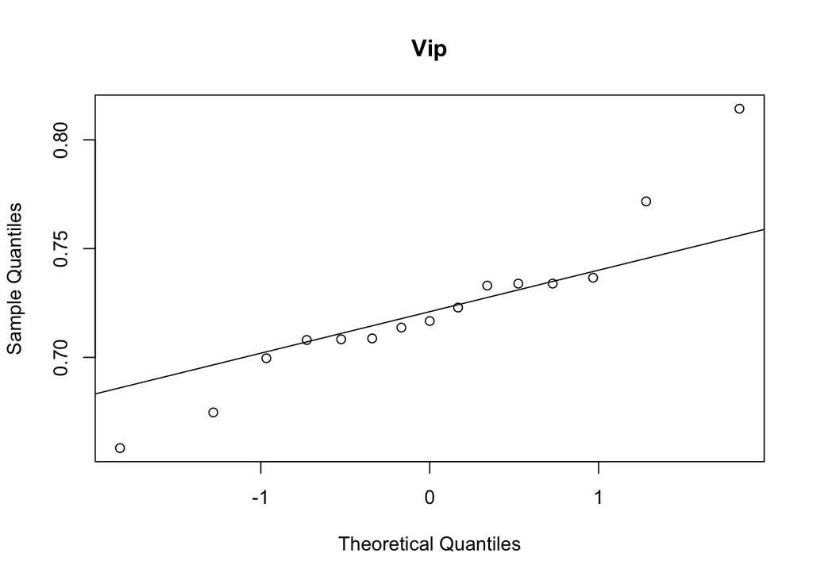

```r
Goegen<- read.csv("/Users/asgeraircool/rdata/Goegen.csv")


formVip=subset(Goegen, subset = (Art =="Vipstjert" ))
formEng=subset(Goegen, subset = (Art =="Engpibe" ))

qqnorm(formVip$Form, main="Vip")
qqline(formVip$Form)
```

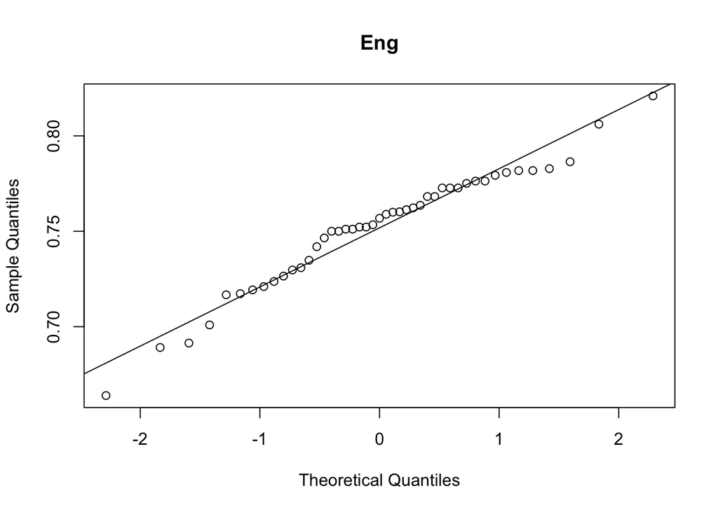

```r
qqnorm(formEng$Form,main="Eng")
qqline(formEng$Form)
```

vi ser på de to plots og ser at de begge snoersig pænt om en linie og er da normaltfordelte. “Vip” har et par outliers men disse tænker jeg ikke er signifikante ved så småt et datasæt

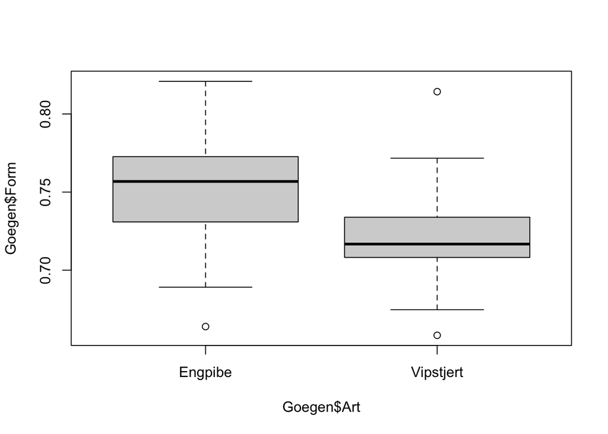

```r
boxplot(Goegen$Form~Goegen$Art)
```

vi kalder eng vip for observationsrække 1 og Eng for observationsrække 2 vi ser at engelpiben måske har en masse der ligger lidt højere mens at størelsen af deres ikke kritiske intervaller ser meget ens ud

opgave 2

$$M_0:X_{i,j}\sim
N(\mu_i,\sigma^2_i)$$

```r
art <-c("Vipstjert","Engpibe")
observationer<-c(length(formVip$Form),length(formEng$Form))
gennemsnit <- c(mean(formVip$Form),mean(formEng$Form))
spredning <- c(sd(formVip$Form),sd(formEng$Form))
nedre<- c(mean(formVip$Form)+qt(0.025,length(formVip$Form)-1)*sd(formVip$Form)/sqrt(length(formVip$Form)),mean(formEng$Form)+qt(0.025,length(formEng$Form)-1)*sd(formEng$Form)/sqrt(length(formEng$Form)))
ovre<-c(mean(formVip$Form)+qt(1-0.025,length(formVip$Form)-1)*sd(formVip$Form)/sqrt(length(formVip$Form)),mean(formEng$Form)+qt(1-0.025,length(formEng$Form)-1)*sd(formEng$Form)/sqrt(length(formEng$Form)))


tabel<-data.frame(art,observationer,gennemsnit,spredning,nedre,ovre)
tabel
```

```
##         art observationer gennemsnit  spredning     nedre      ovre
## 1 Vipstjert            15  0.7222867 0.03689816 0.7018531 0.7427202
## 2   Engpibe            45  0.7519733 0.03108867 0.7426333 0.7613134
```

opgave 3

hypotese
$$h_0:\sigma_0=\sigma_1=\sigma_2\Leftrightarrow
\dfrac{\sigma_1}{\sigma_2}=1$$
vi laver varianstesten

```r
var.test(formVip$Form,formEng$Form)
```

```
##
##  F test to compare two variances
##
## data:  formVip$Form and formEng$Form
## F = 1.4087, num df = 14, denom df = 44, p-value = 0.3793
## alternative hypothesis: true ratio of variances is not equal to 1
## 95 percent confidence interval:
##  0.6462355 3.7442651
## sample estimates:
## ratio of variances
##           1.408657
```

p værdien>0.05 da forkastes hypotesen ikke

opgave 4
$$M_1: X_{i,j}\sim
N(\mu_j,\sigma_0)$$
opstiller modellen under hypotese
$$h_1: \mu_1=\mu_2$$
vi laver testen

```r
t.test(formVip$Form,formEng$Form,var.equal = TRUE)
```

```
##
##  Two Sample t-test
##
## data:  formVip$Form and formEng$Form
## t = -3.0557, df = 58, p-value = 0.003391
## alternative hypothesis: true difference in means is not equal to 0
## 95 percent confidence interval:
##  -0.04913384 -0.01023949
## sample estimates:
## mean of x mean of y
## 0.7222867 0.7519733
```

vi ser at p værdien er mindre end 0.05 da forkastes hypotesen og altså $\mu_1\neq\mu_2$

opgave 5 samme test giver os konfidensintervallet for forskellen

-0.04913384 -0.01023949

den egentlige forskel i opgaven er
$$0.7222867-0.7519733=-0.0296866$$
som jeg ikke vil mene er en særlig stor forskel men når man kigger på variansen og antallet af observationer kan vi stadig konkluderer at der er for stor forskel til at vi kan accepterer at de 2 har ens middelværi